# Exploration of all the datasets

Author

Alexandre Tribut

Published

June 25, 2024

# 1 Cabauw

## 1.1 Measurements

The most issues we have is on measurement data because the methods to measure the wind can sometimes be different from one time to another.

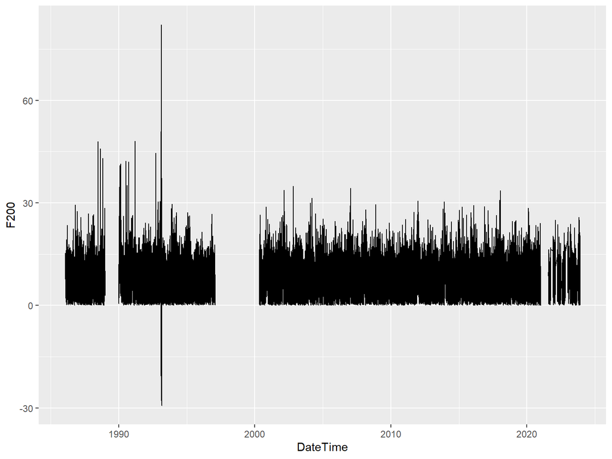

```r
Cabauw_measure <- read.csv("../../../Data/Data_Cabauw/Cabauw_measure.csv")
Cabauw_measure$Year = ymd(Cabauw_measure$Year)
Cabauw_measure$DateTime = ymd_hms(Cabauw_measure$DateTime)


ggplot(Cabauw_measure,aes(x=DateTime,y=F200))+geom_line()
```

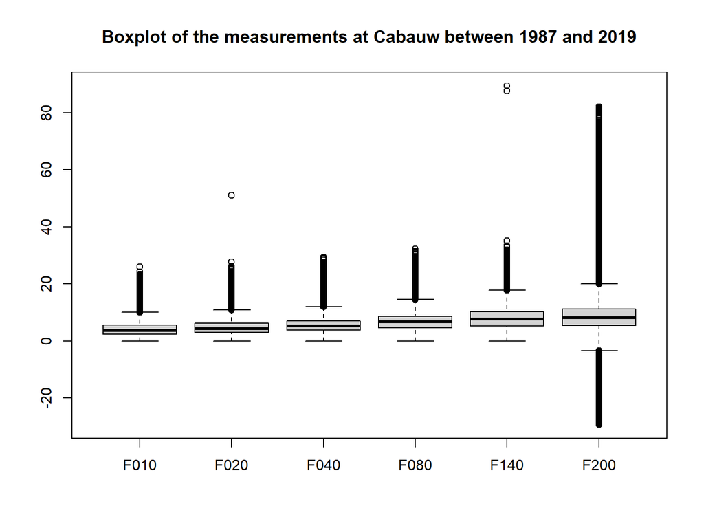

```r
Cabauw_measure = Cabauw_measure[(Cabauw_measure$DateTime >= ymd("2001-07-01") & Cabauw_measure$DateTime  < ymd("2019-07-01")) |
            (Cabauw_measure$DateTime >= ymd("1991-07-01") & Cabauw_measure$DateTime  < ymd("1997-07-01")) |
            (Cabauw_measure$DateTime >= ymd("1987-07-01") & Cabauw_measure$DateTime  < ymd("1989-07-01")) ,]

boxplot(Cabauw_measure[, grepl("^F", names(Cabauw_measure))],main = "Boxplot of the measurements at Cabauw between 1987 and 2019")
```

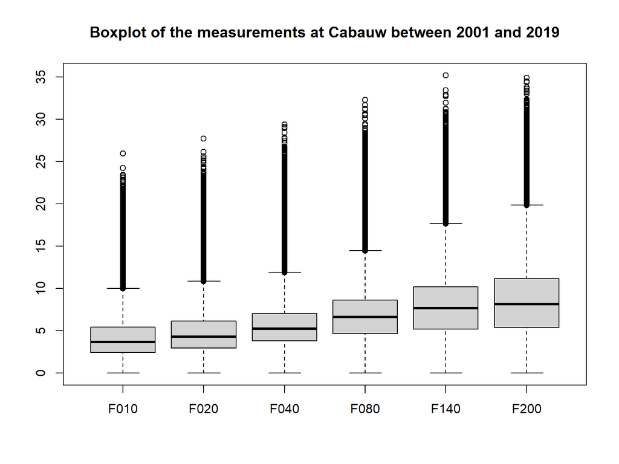

```r
Cabauw_measure = Cabauw_measure[(Cabauw_measure$DateTime >= ymd("2001-07-01") & Cabauw_measure$DateTime  < ymd("2019-07-01")),]

boxplot(Cabauw_measure[, grepl("^F", names(Cabauw_measure))],main = "Boxplot of the measurements at Cabauw between 2001 and 2019")
```

We can see that we have some missing data. Furthermore, at 20m, 140m and 200m, (boxplot 1) there are big outliers in the dataset before 2000 and At 200m, there are some negative values. That is strange because the wind values should be absolute. The integrity of the data is not guarantee and we decided to not take in account any data prior to 2000 before the Cabauw team could exactly find out where it came from.

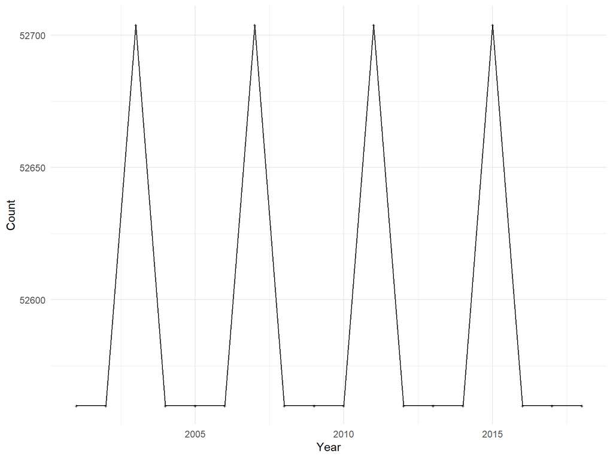

```r
# Create frequency data by grouping by year and counting occurrences
freq_data <- Cabauw_measure %>%
  group_by(year = lubridate::year(Year)) %>%
  summarise(count = n()) %>%
  ungroup()

# Plot the data
ggplot(freq_data, aes(x = year, y = count)) +
  geom_line() +
  geom_point(shape = '+') +
  labs(x = 'Year', y = 'Count') +
  theme_minimal() +
  theme(legend.position = 'bottom')
```

we have almost 150 more value for some years but it is negligible for the total amount of data. These remaining peaks are for the leap years.

## 1.2 Weather models RACMO and KNW

```r
Cabauw_RACMO <- read.csv("../../../Data/Data_RACMO/fulldata.csv")
Cabauw_RACMO$DateTime = ymd_hms(Cabauw_RACMO$DateTime)
Cabauw_RACMO = Cabauw_RACMO[Cabauw_RACMO$Year > min(Cabauw_RACMO$Year) & Cabauw_RACMO$Year < max(Cabauw_RACMO$Year),]

Cabauw_KNW <- read.csv("../../../Data/Data_KNW/modeldata.csv")
Cabauw_KNW$DateTime = ymd_hms(Cabauw_KNW$DateTime)
Cabauw_KNW$Year = year(Cabauw_KNW$Year)
Cabauw_KNW = Cabauw_KNW[Cabauw_KNW$Year > min(Cabauw_KNW$Year) & Cabauw_KNW$Year < max(Cabauw_KNW$Year),]
```

### 1.2.1 Sprectrum

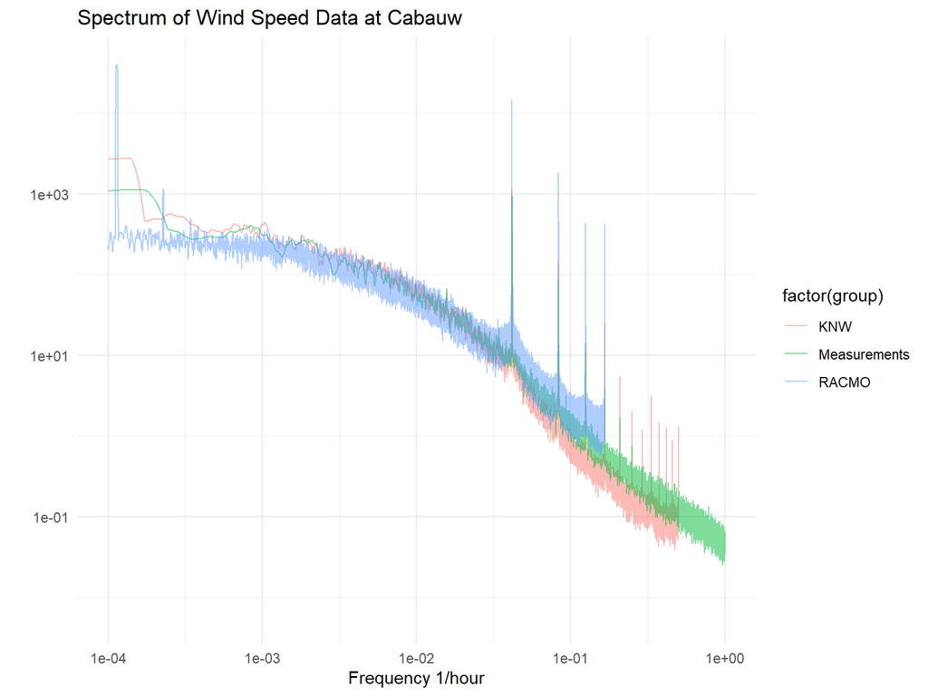

```r
a = cbind(plot_spectrum(Cabauw_KNW,column = 'F010',spans=c(11,31))$spectrum_data,group = 'KNW')
b = cbind(plot_spectrum(Cabauw_RACMO,column = 'w10m',spans=c(11,31))$spectrum_data,group='RACMO')
c = cbind(plot_spectrum(Cabauw_measure,column = 'F010',spans=c(11,31))$spectrum_data,group='Measurements')
df_plot = rbind(a,b,c)

peak = data.frame(x=df_plot$Frequency[which.max(df_plot$Spectrum)])
# print((1/peak)/24)

ggplot(df_plot, aes(x=Frequency,y=Spectrum,color=factor(group)))+
  geom_line(alpha=0.5) +
  scale_y_log10() +
  # geom_vline(data = peak,aes(xintercept=x),color='red',lty='dashed',alpha=0.5) +
  scale_x_log10(limits = c(10^(-4),min(1,max(df_plot$Frequency))))+
  labs(title = "Spectrum of Wind Speed Data at Cabauw",
     x = "Frequency 1/hour",
     y = "") +
  theme_minimal()
```

### 1.2.2 Distributions

#### 1.2.2.1 Whole datasets distributions

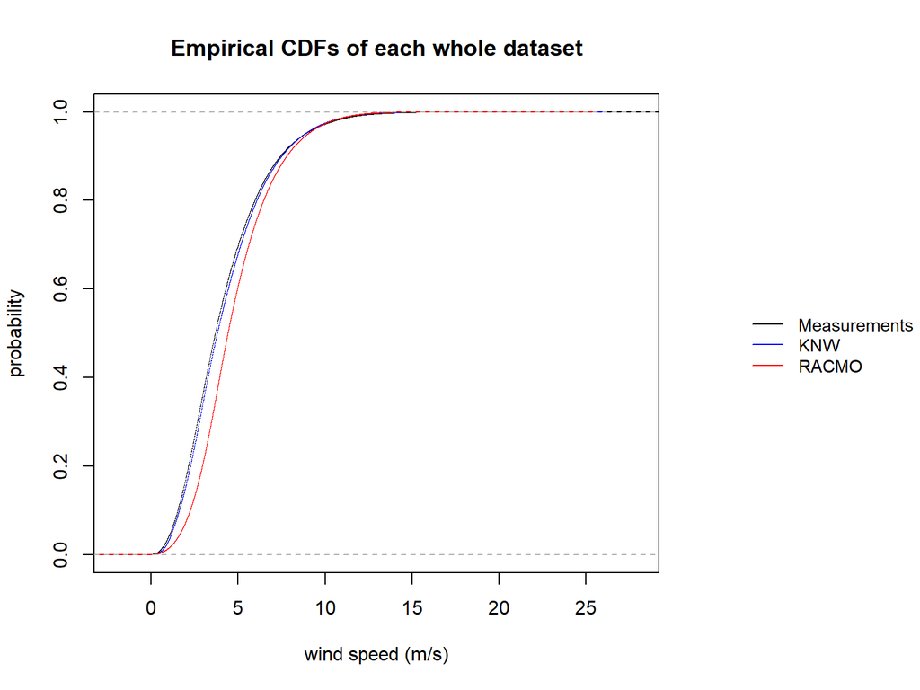

```r
layout(matrix(c(1, 2), 1, 2), widths = c(10, 3))

plot(ecdf(Cabauw_measure$F010),ylim = c(0,1),
     xlab = 'wind speed (m/s)',
     ylab = 'probability',
     main = paste0('Empirical CDFs of each whole dataset'))
lines(ecdf(Cabauw_KNW$F010),col='blue')

bm = BM_select(Cabauw_RACMO,height = 'w10m')
lines(ecdf(Cabauw_RACMO$w10m),col='red')
par(mar = c(1, 1, 1, 2.3))
plot.new()
# Add a legend to the plot
legend(
  "right", # Position of the legend
  legend = c('Measurements','KNW', "RACMO"),
  inset = c(-0.4, 0),
  col = c("black", "blue", "red"),
  lty = c(1, 1, 1),
  bty = "n",
  cex= 0.9,
  xpd=TRUE
)
```

KNW and Measurements distributions fits well. However, we see that there are more greater values in RACMO than in KNW and Measurements.

#### 1.2.2.2 yearly Block Maxima distributions

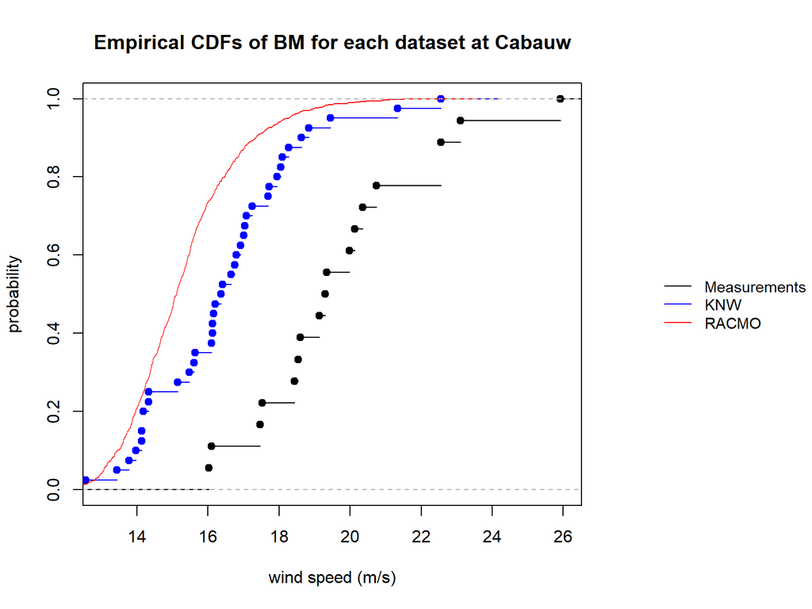

```r
layout(matrix(c(1, 2), 1, 2), widths = c(10, 3))

bm = BM_select(Cabauw_measure)
plot(ecdf(bm$max),ylim = c(0,1), xlim=c(13,26),
     xlab = 'wind speed (m/s)',
     ylab = 'probability',
     main = paste0('Empirical CDFs of BM for each dataset at Cabauw'))
bm = BM_select(Cabauw_KNW)
lines(ecdf(bm$max),col='blue')

bm = BM_select(Cabauw_RACMO,height = "w10m")
lines(ecdf(bm$max),col='red')
par(mar = c(1, 1, 1, 2.3))
plot.new()
# Add a legend to the plot
legend(
  "right", # Position of the legend
  legend = c('Measurements','KNW', "RACMO"),
  inset = c(-0.4, 0),
  col = c("black", "blue", "red"),
  lty = c(1, 1, 1),
  bty = "n",
  cex= 0.9,
  xpd=TRUE
)
```

The distribution of measurements’ yearly maxima is a bit higher than the weather models. This can be explained by the fact that the models are smoothed in areas(2.5km * 2.5km for KNW, 12km * 12km for RACMO). The area is larger for RACMO so that’s maybe why it is even smaller.

#### 1.2.2.3 Peak over Threshold Distributions

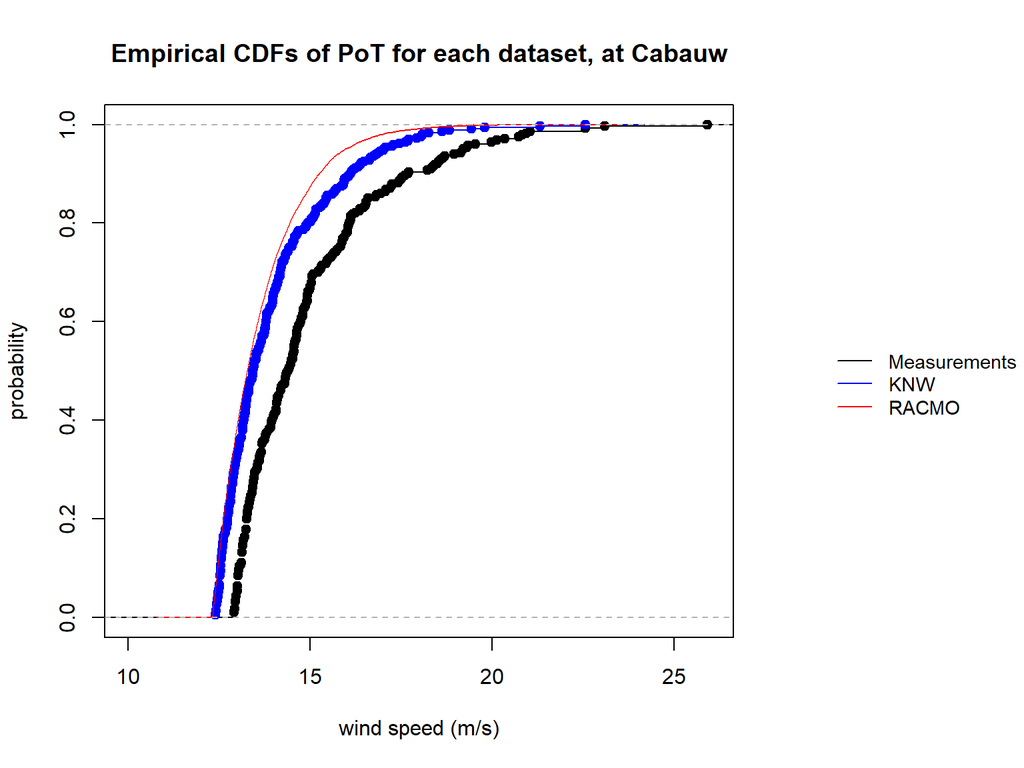

```r
layout(matrix(c(1, 2), 1, 2), widths = c(10, 3))

pot = PoTselect(Cabauw_measure$F010,p = 0.005,sep=6*12)$pot
plot(ecdf(pot),ylim = c(0,1), xlim=c(10,26),
     xlab = 'wind speed (m/s)',
     ylab = 'probability',
     main = paste0('Empirical CDFs of PoT for each dataset, at Cabauw'))

pot = PoTselect(Cabauw_KNW$F010,p = 0.005,sep=12)$pot
lines(ecdf(pot),col='blue')


pot = PoTselect(Cabauw_RACMO$w10m,p = 0.005,sep=4)$pot
lines(ecdf(pot),col='red')
par(mar = c(1, 1, 1, 2.3))
plot.new()
# Add a legend to the plot
legend(
  "right", # Position of the legend
  legend = c('Measurements','KNW', "RACMO"),
  inset = c(-0.4, 0),
  col = c("black", "blue", "red"),
  lty = c(1, 1, 1),
  bty = "n",
  cex= 0.9,
  xpd=TRUE
)
```

> We can also draw QQ-plots and PP-plots but it doesn’t give more hints about the distributions.

# 2 Schiphol

## 2.1 Measurements

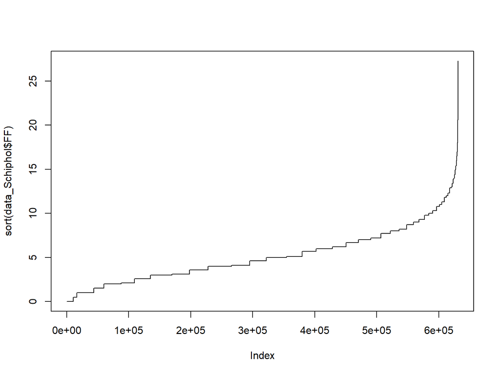

```r
data_Schiphol <- read.csv("../../../Data/Data_Schiphol/dataSchiphol.csv")
data_Schiphol$DateTime = ymd_hms(data_Schiphol$DateTime)
data_Schiphol = data_Schiphol[data_Schiphol$Year > min(data_Schiphol$Year) & data_Schiphol$Year < max(data_Schiphol$Year),]

plot(sort(data_Schiphol$FF),type='l')
```

```r
print(paste("Unique wind speed values:",length(unique(data_Schiphol$FF))))
```

```
[1] "Unique wind speed values: 74"
```

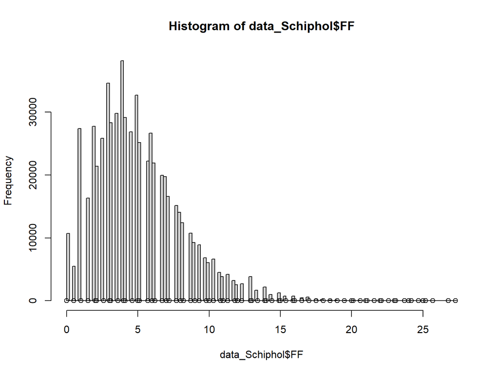

```r
hist(data_Schiphol$FF,breaks = 150)
points(data_Schiphol$FF,rep(0,length(data_Schiphol$FF)))
```

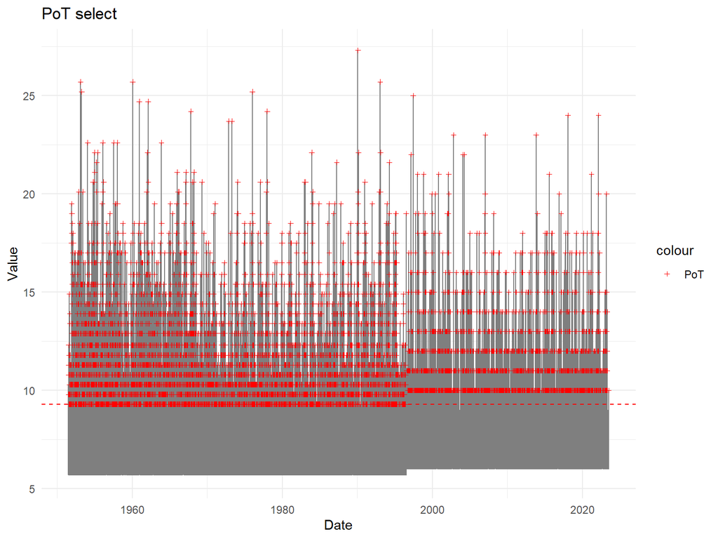

```r
pot = PoTselect_2(data_Schiphol$FF,0.1,12)

# mw = find_max_window(data_Schiphol$FF,pot$ind,24*30)

plot_extremes(pot,data_Schiphol,col='FF') #+ geom_point(data = data_Schiphol[pot1$ind, ], aes(colour = "PoT1"), size = 3,pch=7)
```

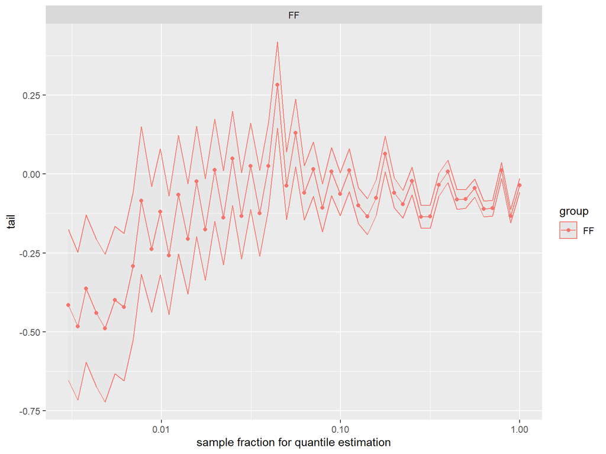

```r
fit <- FitGP_MLE2(pot$pot, 1, N= 0, r11= 1, l0= round(10^(seq(-2.5, -0, 0.05))*length(pot$pot))-1, sigma= Inf, metadata= list(label='FF'))
tailindexplot_2(list(fit))
```

### 2.1.1 deal with discretization

Because Schiphol data is very discretized, we have the idea of adding a little noise to the data to smooth the result of tail index estimation.

To tackle this, we have the idea to add a noise to the data.

$$new\_data = data + noise$$
We can do so by using a Gaussian Noise or a uniform noise :

#### 2.1.1.1 Gaussian noise

For the Gaussian noise, we can use a fraction of the standard deviation of the data.

$$noise \sim \mathcal{N}(0,\sigma) \text{, with } \sigma = sd(data)*0.1$$

We have to set the negative values obtained by adding a too large negative noise to 0 because the wind can’t be negative.

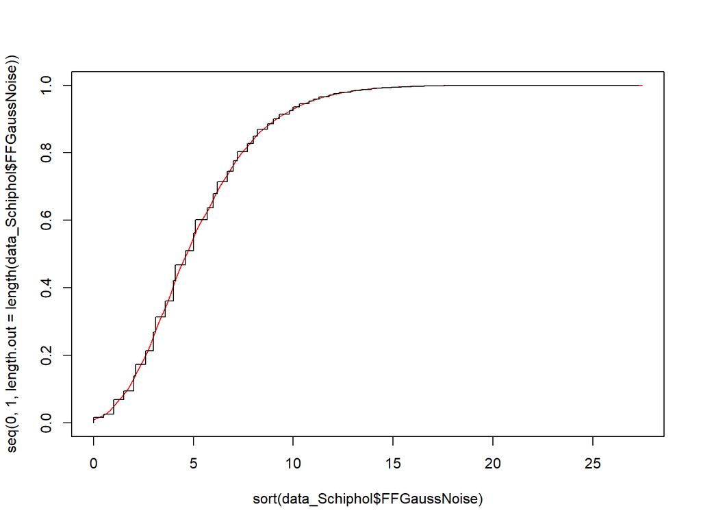

```r
sigma = sd(data_Schiphol$FF)*0.1
data_Schiphol$FFGaussNoise = data_Schiphol$FF + rnorm(length(data_Schiphol$FF), mean = 0, sd = sigma)
data_Schiphol$FFGaussNoise[data_Schiphol$FFGaussNoise<0] <- 0

plot(sort(data_Schiphol$FFGaussNoise),type='l',seq(0,1,length.out=length(data_Schiphol$FFGaussNoise)),col='red')
lines(sort(data_Schiphol$FF),seq(0,1,length.out=length(data_Schiphol$FFGaussNoise)))
```

It seems to smooth the data while preserving the trend so that’s good. The estimated tail index may be a bit higher because the noise can introduce a little bias. We consider that this bias is negligible.

#### 2.1.1.2 Uniform noise

For the uniform noise, we can take a noise that follows a uniform distribution of the maximum width between two values in the sorted sample and centered to 0. We also have to avoid negative values.

$$noise \sim \mathcal{U}([-a/2,a/2]) \text{, with } a = max(X_{i:n} - X_{i+1:n} \mid 1\leq i\leq n-1)$$

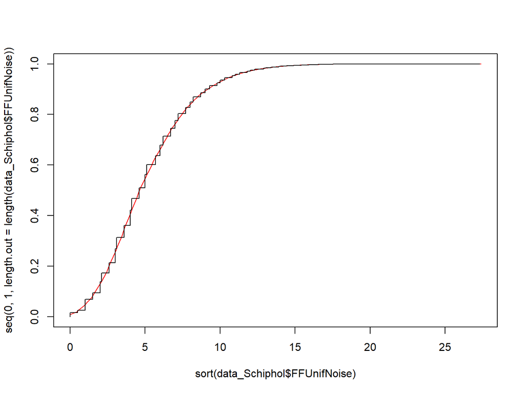

```r
I = max(diff(sort(data_Schiphol$FF)))

data_Schiphol$FFUnifNoise = data_Schiphol$FF + runif(length(data_Schiphol$FF), min = -I/2, max = I/2)
data_Schiphol$FFUnifNoise[data_Schiphol$FFUnifNoise<0] <- 0

plot(sort(data_Schiphol$FFUnifNoise),type='l',seq(0,1,length.out=length(data_Schiphol$FFUnifNoise)),col='red')
lines(sort(data_Schiphol$FF),seq(0,1,length.out=length(data_Schiphol$FFUnifNoise)))
```

the data are also smoothed and the trend is also preserved.

We don’t see much difference between the two smoothing so we can choose one of them to be used in the analysis. We have a preference for the uniform noise because it should more preserve the trend and order of the sorted data.

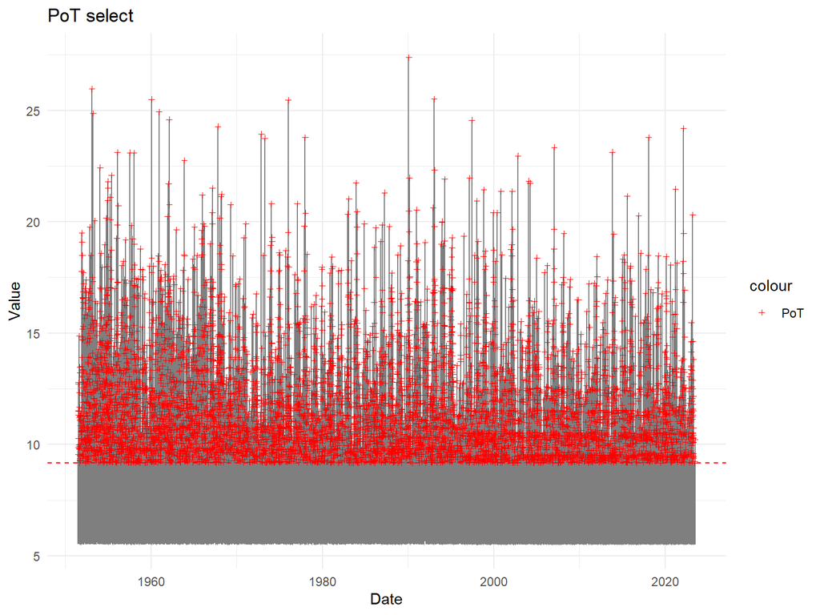

```r
pot = PoTselect_2(data_Schiphol$FFUnifNoise,0.1,12)

# mw = find_max_window(data_Schiphol$FF,pot$ind,24*30)

plot_extremes(pot,data_Schiphol,col='FFUnifNoise') #+ geom_point(data = data_Schiphol[pot1$ind, ], aes(colour = "PoT1"), size = 3,pch=7)
```

The peaks are now very spread and more representatives.

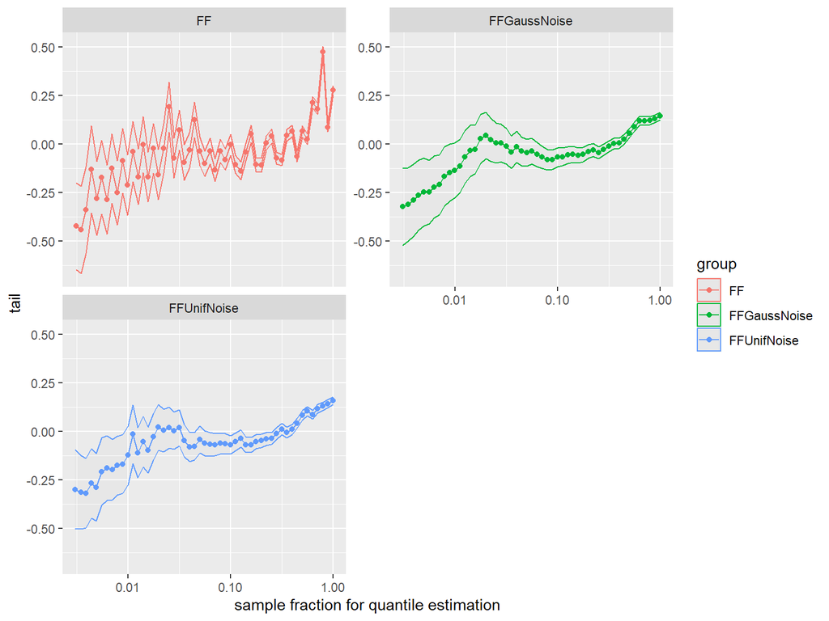

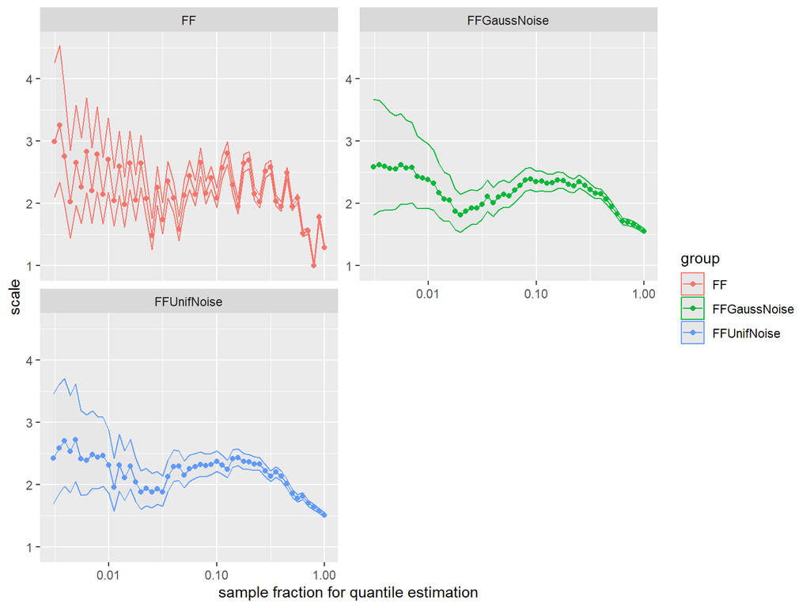

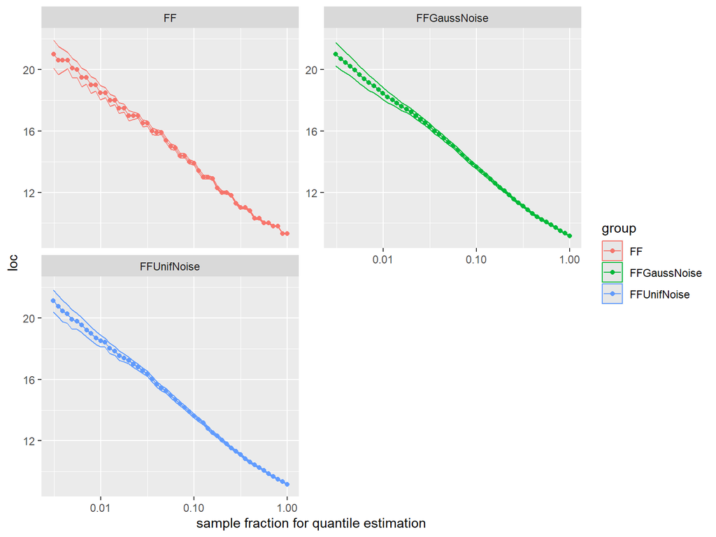

```r
tailindexplot_all_heights(data_Schiphol,1,method="GP",fix_y = TRUE)
```